# EXPLO : Statistiques exploratoires

1.Préparation des données

Auteur·rice

Claude Grasland, Sophie Baudet-Michel

Date de publication

2024-05-13

```r
library(knitr)
library(sf)
```

L’analyse multivariée suppose une préparation des données à la fois sur le plan statistique et sur le plan cartographie. On va prendre ici l’exemple de la préparation de fichiers pour les données de 2004 par gouvernorat. Mais on pourra facilement effectuer la même analyse par délégation ou pour l’année 2014.

## Données statistiques

### Importation du fichier .csv

Les données se trouvent dans un dossier contenant une large base de données sur les résultats des recensements de 2004 et 2014 par gouvernorats

```r
# Importation du fichier .csv
don <- read.table("RP_Tunisie/data/don_gou.csv",
                  header = TRUE,   # Il y a un en-tête
                  sep = ";",       # le séparateur est ;
                  encoding = "UTF-8"  # Encodage pour français et arabe
                  )
kable(head(don))
```

| gou_code | gou_nom | reg_code | reg_nom | popto_2004 | popco_2004 | immig_2004 | emigr_2004 | menag_2004 | ordin_2004 | porta_2004 | telef_2004 | popto_2014 | popco_2014 | immig_2014 | emigr_2014 | menag_2014 | ordin_2014 | porta_2014 | telef_2014 | popto_2010 | surfa_2010 | idr_2011 |
| --- | --- | --- | --- | --- | --- | --- | --- | --- | --- | --- | --- | --- | --- | --- | --- | --- | --- | --- | --- | --- | --- | --- |
| AN | Ariana | NE | Nord-est | 422246 | 422246 | 65078 | 27182 | 101327 | 16541 | 60099 | 47045 | 576088 | 576088 | 79080 | 38651 | 151397 | 76535 | 149691 | 46088 | 491515 | 415.156 | 0.4741429 |
| BA | Ben Arous | NE | Nord-est | 505773 | 505773 | 79305 | 42366 | 117901 | 15349 | 71335 | 55707 | 631842 | 631842 | 73056 | 46057 | 163811 | 83629 | 162000 | 51779 | 571465 | 656.871 | 0.4789167 |
| BJ | Beja | NO | Nord-ouest | 304501 | 304501 | 11283 | 20884 | 68584 | 2219 | 22075 | 15384 | 303032 | 303032 | 9439 | 17203 | 76827 | 14707 | 72252 | 8480 | 305650 | 3740.000 | 0.2662222 |
| BZ | Bizerte | NE | Nord-est | 524128 | 524128 | 24397 | 27220 | 119976 | 5973 | 46459 | 35284 | 568219 | 568219 | 20530 | 26531 | 142532 | 40550 | 137920 | 23394 | 544526 | 3486.380 | 0.3403571 |
| GB | Gabes | SE | Sud-est | 342630 | 342630 | 24025 | 26392 | 69703 | 4185 | 32141 | 27744 | 374300 | 374300 | 22114 | 24017 | 84783 | 28766 | 83313 | 17413 | 359749 | 7166.260 | 0.2706000 |
| GF | Gafsa | SO | Sud-ouest | 323709 | 323709 | 14275 | 22058 | 65926 | 4489 | 28742 | 23015 | 337331 | 337331 | 12929 | 19109 | 77964 | 22513 | 76023 | 12269 | 336588 | 7807.800 | 0.1708182 |

### Création et recodage des variables

```r
# Création ou recodage des variables
code<-don$gou_code
nom<-don$gou_nom
popto <- don$popto_2004
menag <- don$menag_2004
tailm <- don$popto_2004/don$menag_2004
densi <- don$popto_2004/don$surfa_2010
#urban <- 100*don$popco_2004/don$popto_2004
mobil <- 100*(don$immig_2004+don$emigr_2004)/don$popto_2004
acmig <- 100*(don$immig_2004-don$emigr_2004)/don$popto_2004
ordin <- 100*don$ordin_2004/don$menag_2004
porta <- 100*don$porta_2004/don$menag_2004

# Affichage
tab<-data.frame(code,nom, popto,menag, tailm, densi,mobil, acmig, ordin, porta)
kable(tab,
      digits = c(0,0,0,0,2,1,1,1,1,1), # decimales par colonnes
      caption = "Tableau de données 2004"   # Titre du tableau
      )
```

Tableau de données 2004

| code | nom | popto | menag | tailm | densi | mobil | acmig | ordin | porta |
| --- | --- | --- | --- | --- | --- | --- | --- | --- | --- |
| AN | Ariana | 422246 | 101327 | 4.17 | 1017.1 | 21.8 | 9.0 | 16.3 | 59.3 |
| BA | Ben Arous | 505773 | 117901 | 4.29 | 770.0 | 24.1 | 7.3 | 13.0 | 60.5 |
| BJ | Beja | 304501 | 68584 | 4.44 | 81.4 | 10.6 | -3.2 | 3.2 | 32.2 |
| BZ | Bizerte | 524128 | 119976 | 4.37 | 150.3 | 9.8 | -0.5 | 5.0 | 38.7 |
| GB | Gabes | 342630 | 69703 | 4.92 | 47.8 | 14.7 | -0.7 | 6.0 | 46.1 |
| GF | Gafsa | 323709 | 65926 | 4.91 | 41.5 | 11.2 | -2.4 | 6.8 | 43.6 |
| JE | Jendouba | 416608 | 92877 | 4.49 | 134.3 | 10.1 | -2.4 | 2.5 | 32.9 |
| KB | Kebili | 143218 | 26549 | 5.39 | 6.4 | 10.0 | -1.2 | 3.4 | 50.7 |
| KF | Le Kef | 258790 | 59107 | 4.38 | 50.9 | 13.7 | -4.3 | 3.0 | 33.0 |
| KR | Kairouan | 546209 | 107923 | 5.06 | 82.8 | 9.8 | -4.2 | 1.7 | 29.5 |
| KS | Kasserine | 412278 | 79448 | 5.19 | 50.0 | 9.7 | -4.1 | 1.6 | 31.2 |
| ME | Medenine | 432503 | 90000 | 4.81 | 47.2 | 11.9 | 0.6 | 4.7 | 49.5 |
| MH | Mahdia | 377853 | 79197 | 4.77 | 132.3 | 7.4 | -0.6 | 3.3 | 42.8 |
| MN | Manubah | 335912 | 70750 | 4.75 | 302.0 | 14.6 | 2.9 | 6.6 | 43.5 |
| MS | Monastir | 455590 | 100967 | 4.51 | 458.2 | 11.2 | 3.7 | 7.8 | 56.0 |
| NB | Nabeul | 693890 | 162691 | 4.27 | 245.3 | 9.2 | 1.0 | 6.1 | 46.5 |
| SF | Sfax | 855256 | 198565 | 4.31 | 122.9 | 16.9 | 1.3 | 7.8 | 47.6 |
| SL | Siliana | 233985 | 48448 | 4.83 | 50.4 | 12.3 | -5.0 | 2.2 | 32.7 |
| SS | Sousse | 544413 | 124519 | 4.37 | 239.8 | 17.6 | 4.0 | 9.6 | 56.7 |
| SZ | Sidi Bou Zid | 395506 | 76771 | 5.15 | 53.7 | 8.7 | -3.6 | 1.2 | 36.7 |
| TA | Tataouine | 143524 | 26575 | 5.40 | 3.7 | 13.5 | -1.7 | 3.5 | 45.8 |
| TO | Tozeur | 97526 | 20485 | 4.76 | 17.4 | 10.4 | -0.6 | 5.0 | 43.6 |
| TU | Tunis | 983861 | 244018 | 4.03 | 4064.3 | 26.4 | -2.8 | 14.0 | 60.5 |
| ZA | Zaghouan | 160963 | 33532 | 4.80 | 56.1 | 9.4 | -0.5 | 2.7 | 37.9 |

### Sauvegarde dans un nouveau dossier

On enregistre les données dans un dossier appelé EXPLO au format .csv et au format .RDS

```r
# Sauvegarde aux formats .RDS et .csv
saveRDS(tab, "EXPLO/don2004.RDS") # sauvegarde au format interne de R

write.table(tab, "EXPLO/don2004.csv",
            sep=";",
            row.names=F,
            fileEncoding = "UTF-8")
```

## Données géométriques

### Importation

On va importer maintenant le fonds cartographique correspondant aux unités spatiales choisies (ici, les gouvernorats).

```r
# Importation du shapefile des gouvernorats à l'aide de sf
map<-sf::st_read("RP_Tunisie/geom/map_gou.shp")
```

### Visualisation

On cartographie rapidement le fonds de carte pour voir s’il est correct

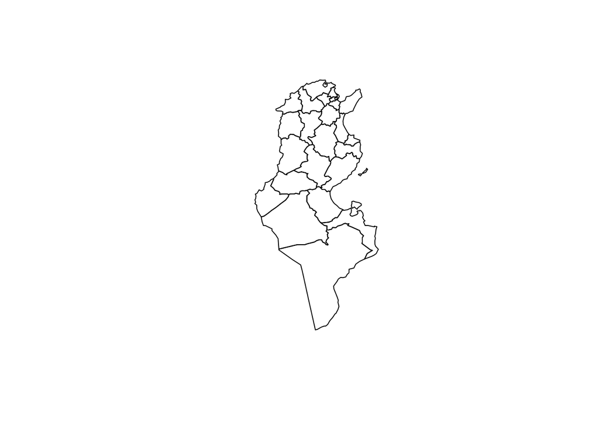

```r
plot(map$geometry)
```

### Jointure

On effectue ensuite la jointure avec les données statistiques et on obtient un fichier de type sf (spatial features)

```r
# Jointure des données statistiques et géométriques
map<- merge(map, tab, by.x="gou_code",by.y="code")
class(map)
```

```
[1] "sf"         "data.frame"
```

### Vérification

On vérifie que la jointure est correcte en cartographiant une variable rapidement :

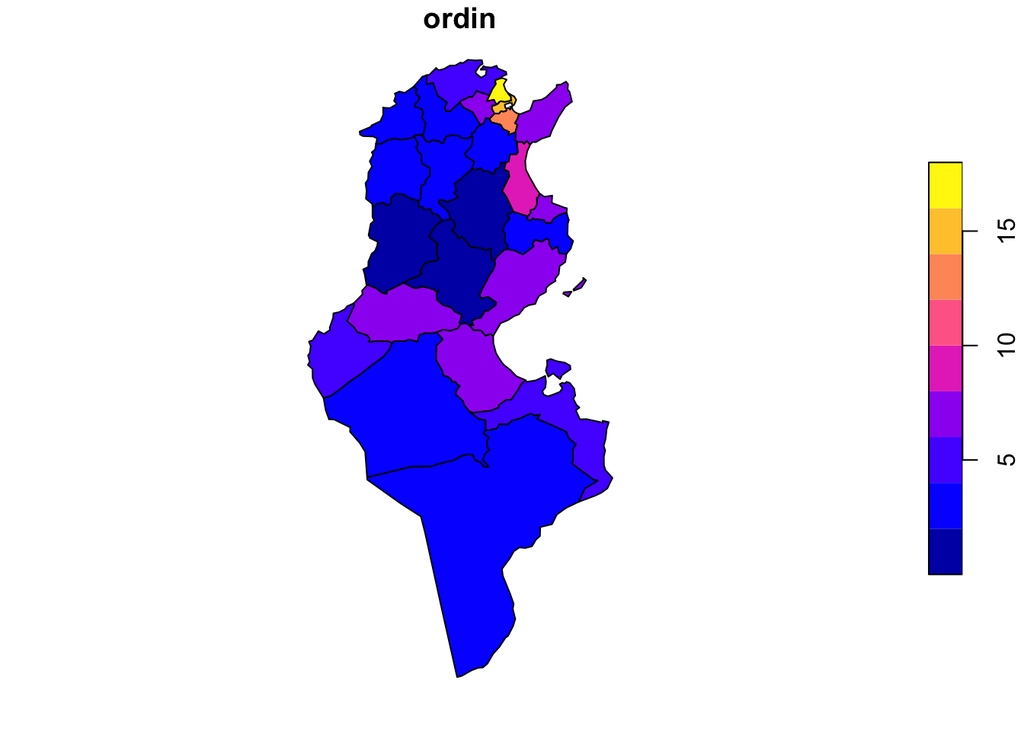

```r
plot(map["ordin"])
```

### Exportation

```r
# Sauvegarde aux formats .RDS  (et éventuellement .shp et  .geojson)

saveRDS(map, "EXPLO/map2004.RDS") ## Format interne de R

#sf::st_write(map, "EXPLO/map2004.geojson",delete_dsn = T)  ## Format geojson

#sf::st_write(map, "EXPLO/map2004.shp",delete_dsn = T)
```